# CRISP-DM E2 - Entendimiento de la data

amanosalva

19 de noviembre de 2018

## Descripción del problea

Los modelos analíticos para el manejo de los seguros de accidentes se están usando por muchas instituciones y están dando resultados exitosos en todo el mundo. Los modelos analíticos de se pueden definir como un conjunto de métodos y técnicas cuantitativas usados para predecir la probabilidad de que un cliente falle (Sea siniestroso) y en consecuencia no se recupere el rédito otorgado por alguna institución.

## Reto

Identifique los clientes que tienen una alta probabilidad de siniestro.

### 1. Instalación y activación de librerías necesarias:

```r
#install.packages('DataExplorer', dependencies = T)
library(mlr)
library(dplyr)
library(DataExplorer)
```

### 2. Ingesta de la data

```r
train <- read.csv("train_seguros.csv", header = T)
```

### 3. Análisis exploratorio

**Graficando los valores faltantes para una mejor visión global:**

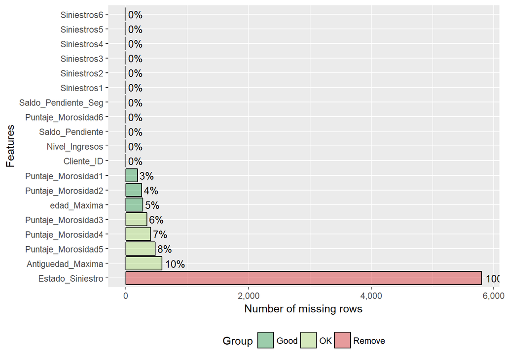

```r
PlotMissing(train)
```

**En caso de querer saber los valores exactos de los NA:**

```r
summarizeColumns(train)
```

```
##                   name    type   na         mean         disp     median
## 1           Cliente_ID integer    0 3.967334e+05 2.302859e+05 403865.000
## 2    Antiguedad_Maxima integer  587 4.984711e+01 4.705053e+01     34.000
## 3          edad_Maxima integer  273 1.071286e+00 1.158293e+00      1.000
## 4       Nivel_Ingresos numeric    0 3.240984e+03 6.157723e+03   1100.315
## 5      Saldo_Pendiente integer    0 1.993103e-01 6.790026e-01      0.000
## 6   Puntaje_Morosidad1 integer  186 2.434984e-01 8.912083e-01      0.000
## 7   Puntaje_Morosidad2 integer  256 2.202381e-01 8.424607e-01      0.000
## 8   Puntaje_Morosidad3 integer  340 1.935897e-01 7.810702e-01      0.000
## 9   Puntaje_Morosidad4 integer  403 1.854734e-01 7.443064e-01      0.000
## 10  Puntaje_Morosidad5 integer  476 1.722389e-01 7.073136e-01      0.000
## 11  Puntaje_Morosidad6 numeric    0 4.970516e+03 2.201641e+04      0.000
## 12 Saldo_Pendiente_Seg integer    0 7.837931e-01 4.890399e+00      0.000
## 13         Siniestros1 integer    0 6.960345e-01 4.746389e+00      0.000
## 14         Siniestros2 integer    0 6.458621e-01 4.661810e+00      0.000
```

[output cut: 25 more lines]

Las siguientes columnas tienen valores NA: Antiguedad_Maxima - 587 edad_Maxima - 273 Puntaje_MorosidadX, donde 1 <= x <= 5

**Viendo la estructura de la data**

```r
PlotStr(train)
```

[output not shown]

Curiosamente vemos que la variable “Siniestro6” tiene tres niveles: "“,”si“,”no". Ese espacio en blanco debe ser considerado como ata faltante? Habría que ver su proporción o influencia.

```r
levels(train$Siniestros6)
```

```
## [1] ""   "no" "si"
```

**Distribuciones**

Viendo las distribuciones numéricas:

*Separamos solo los numéricos*

```r
train_numericos <- select_if(train, is.numeric)
names(train_numericos)
```

```
##  [1] "Cliente_ID"          "Antiguedad_Maxima"   "edad_Maxima"
##  [4] "Nivel_Ingresos"      "Saldo_Pendiente"     "Puntaje_Morosidad1"
##  [7] "Puntaje_Morosidad2"  "Puntaje_Morosidad3"  "Puntaje_Morosidad4"
## [10] "Puntaje_Morosidad5"  "Puntaje_Morosidad6"  "Saldo_Pendiente_Seg"
## [13] "Siniestros1"         "Siniestros2"         "Siniestros3"
## [16] "Siniestros4"         "Siniestros5"
```

*Graficamos histogramas:*

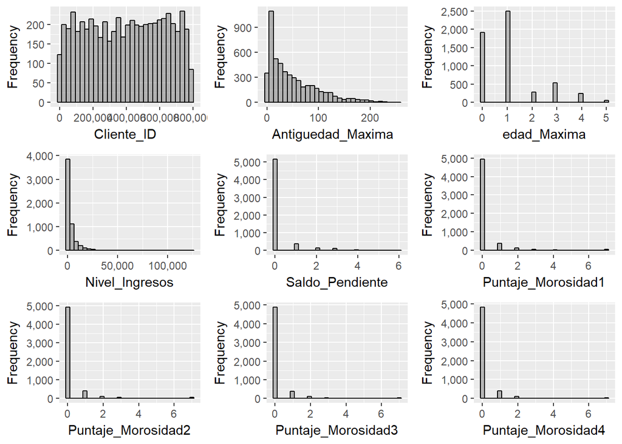

```r
HistogramContinuous(train_numericos[1:9])
```

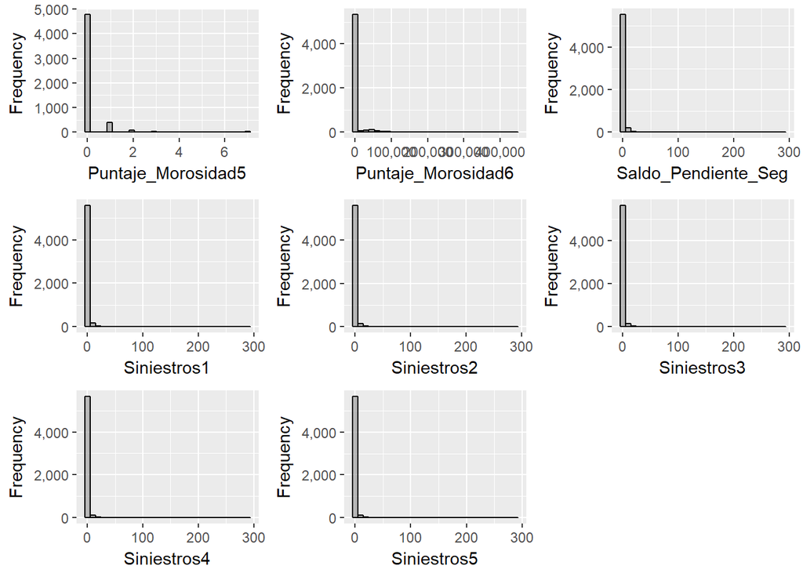

```r
HistogramContinuous(train_numericos[10:length(train_numericos)])
```

Viendo las distribuciones categóricas:

*Separamos solo categóricos*

```r
train_factores <- select_if(train, is.factor)
names(train_factores)
```

```
## [1] "Siniestros6"
```

*Graficamos barras:*

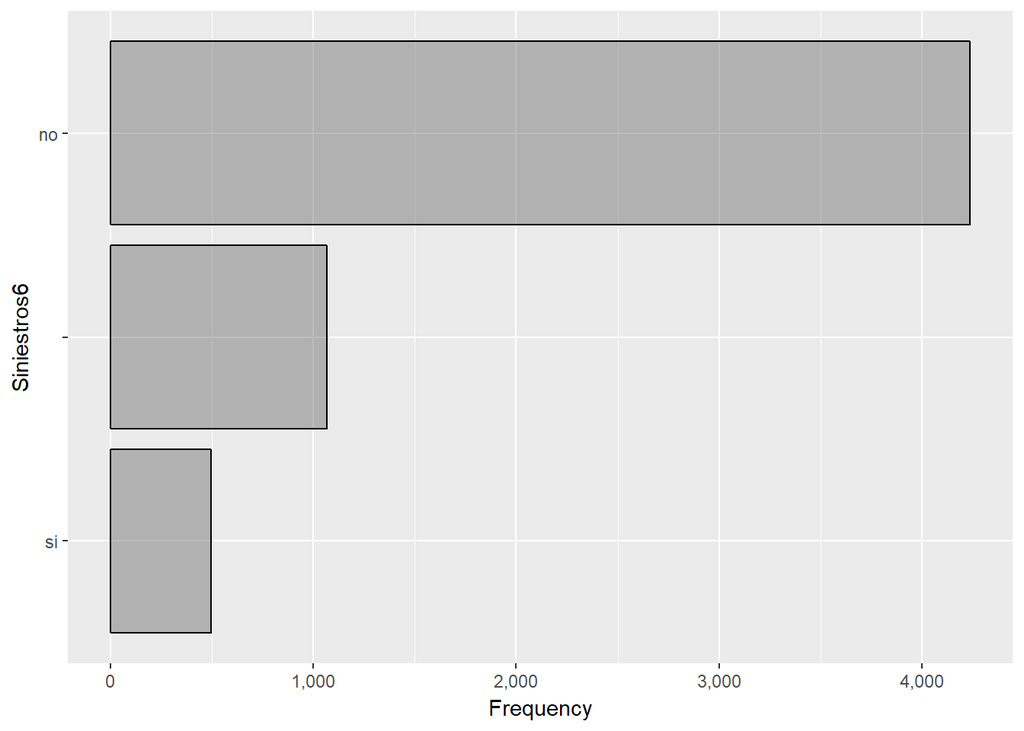

```r
BarDiscrete(train_factores)
```

**Correlaciones**

*Viendo las correlaciones continuas:*

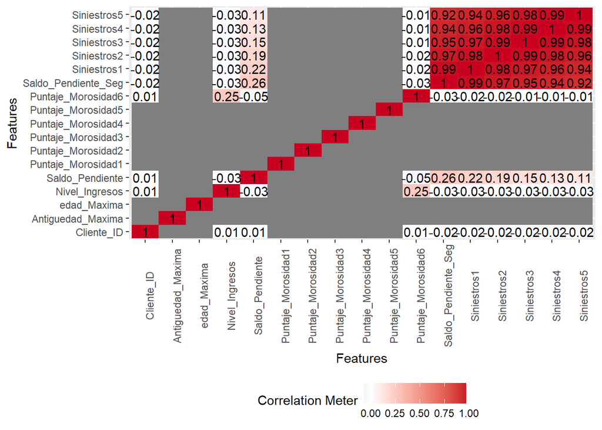

```r
CorrelationContinuous(train_numericos)
```

*Viendo las correlaciones discretas:*

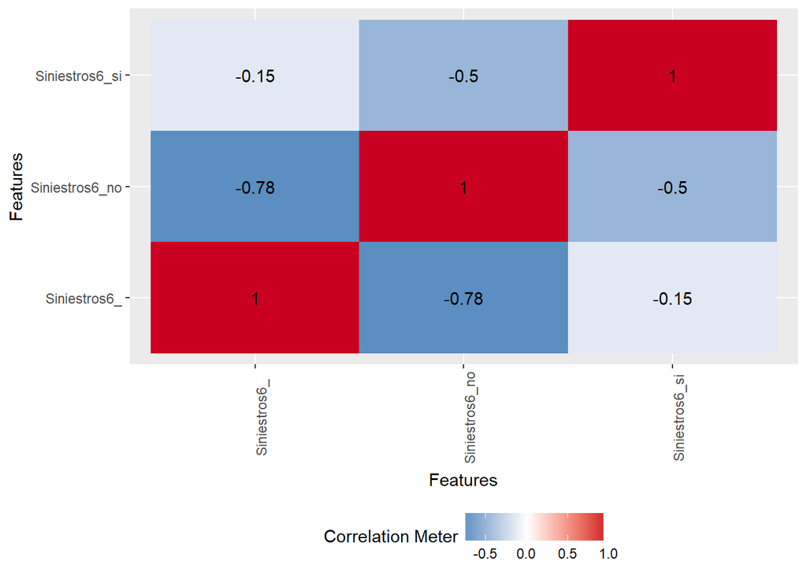

```r
CorrelationDiscrete(train_factores)
```